# Programmation et rédaction

## obtenir de l'aide

Dans une cellule de code tapez l'une de 2 commandes suivantes et éxecutez la cellule :

```
texte?
%pinfo texte
```

## fonctions magiques (en fonction du langage)

```python
%lsmagic
```

```
Available line magics:
%alias  %alias_magic  %autoawait  %autocall  %automagic  %autosave  %bookmark  %cat  %cd  %clear  %colors  %conda  %config  %connect_info  %cp  %debug  %dhist  %dirs  %doctest_mode  %ed  %edit  %env  %gui  %hist  %history  %killbgscripts  %ldir  %less  %lf  %lk  %ll  %load  %load_ext  %loadpy  %logo…

Available cell magics:
%%!  %%HTML  %%SVG  %%bash  %%capture  %%debug  %%file  %%html  %%javascript  %%js  %%latex  %%markdown  %%perl  %%prun  %%pypy  %%python  %%python2  %%python3  %%ruby  %%script  %%sh  %%svg  %%sx  %%system  %%time  %%timeit  %%writefile

Automagic is ON, % prefix IS NOT needed for line magics.
```

On distingue des commandes magiques qui s'appliquent à une instruction et des commandes magiques qui s'appliquent à toute une cellule de code.

Pour obtenir de l'aide sur une commande magique : **%nom_commande?**  
Par exemple : **%timeit?** : commande magique permettant d'évaluer le temps d'exécution d'une expression ou instruction Python.

### écrire dans un fichier

Dans une cellule de code, tapez les instructions suivantes :

```
%%file hello.py
un_message = "Hello from Notebook"
print(un_message)
```

Dans une autre cellule, vérifiez que votre fichier hello.py a bien été créé (simplement à l'aide de la commande magique `%ls`) et affichez son contenu à l'aide de la commande système `cat` si vous travaillez sous MAC ou Linux sinon `type` sous Windows:

```
%ls hello.py
print("\r\nDisplay file Hello.py :")
print('-------------------------')
!cat hello.py  # sous MAC ou Linux
!type hello.py  # sous Windows
```

### exécuter un script

Dans une cellule de code, tapez la commande `%run script.py`. Par exemple :

```
%run Hello.py
```

Notez que les variables du script sont connues de l'interpréteur après exécution.

## introspection du code (en fonction du langage)

```python
help(2)
```

```
Help on int object:

class int(object)
 |  int([x]) -> integer
 |  int(x, base=10) -> integer
 |  Convert a number or string to an integer, or return 0 if no arguments
 |  are given.  If x is a number, return x.__int__().  For floating point
 |  numbers, this truncates towards zero.
 |  If x is not a number or if base is given, then x must be a string,
 |  bytes, or bytearray instance representing an integer literal in the
 |  given base.  The literal can be preceded by '+' or '-' and be surrounded
 |  by whitespace.  The base defaults to 10.  Valid bases are 0 and 2-36.
 |  Base 0 means to interpret the base from the string as an integer literal.
 |  >>> int('0b100', base=0)
 |  4
 |  Built-in subclasses:
 |      bool
 |  Methods defined here:
 |  __abs__(self, /)
 |      abs(self)
 |  __add__(self, value, /)
 |      Return self+value.
 |  __and__(self, value, /)
 |      Return self&value.
 |  __bool__(self, /)
 |      self != 0
 |  __ceil__(...)
 |      Ceiling of an Integral returns itself.
 |  __divmod__(self, value, /)
 |      Return divmod(self, value).
 |  __eq__(self, value, /)
 |      Return self==value.
 |  __float__(self, /)
 |      float(self)
 |  __floor__(...)
 |      Flooring an Integral returns itself.
 |  __floordiv__(self, value, /)
 |      Return self//value.
 |  __format__(self, format_spec, /)
 |      Default object formatter.
```

[output cut: 127 more lines]

```
 |        Indicates whether two's complement is used to represent the integer.
 |  ----------------------------------------------------------------------
 |  Static methods defined here:
 |  __new__(*args, **kwargs) from builtins.type
 |      Create and return a new object.  See help(type) for accurate signature.
 |  ----------------------------------------------------------------------
 |  Data descriptors defined here:
 |  denominator
 |      the denominator of a rational number in lowest terms
 |  imag
 |      the imaginary part of a complex number
 |  numerator
 |      the numerator of a rational number in lowest terms
 |  real
 |      the real part of a complex number
```

```python
dir(2)
```

```
['__abs__',
 '__add__',
 '__and__',
 '__bool__',
 '__ceil__',
 '__class__',
 '__delattr__',
 '__dir__',
 '__divmod__',
 '__doc__',
 '__eq__',
 '__float__',
 '__floor__',
 '__floordiv__',
 '__format__',
 '__ge__',
 '__getattribute__',
 '__getnewargs__',
 '__gt__',
 '__hash__',
 '__index__',
 '__init__',
 '__init_subclass__',
 '__int__',
 '__invert__',
 '__le__',
 '__lshift__',
 '__lt__',
 '__mod__',
 '__mul__',
 '__ne__',
 '__neg__',
 '__new__',
 '__or__',
 '__pos__',
 '__pow__',
 '__radd__',
 '__rand__',
 '__rdivmod__',
 '__reduce__',
```

[output cut: 16 more lines]

```
 '__str__',
 '__sub__',
 '__subclasshook__',
 '__truediv__',
 '__trunc__',
 '__xor__',
 'as_integer_ratio',
 'bit_length',
 'conjugate',
 'denominator',
 'from_bytes',
 'imag',
 'numerator',
 'real',
 'to_bytes']
```

tracer une courbe Nous n'avons pas encore abordé les bibliothèques de visualisation graphique (ici usage de module pyplot de la librairie matplotlib) mais cet exemple illustre l'intégration des graphiques matplotlib dans un notebook à l'aide de la commande magique %matplotlib inline. Copiez-collez le code ci-après dans une cellule de code et exécutez-la.

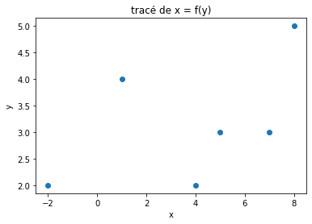

```python
import matplotlib.pyplot as plt
%matplotlib inline

# données
x = [1, -2, 5, 7, 4, 8]
y = [4, 2, 3, 3, 2, 5]

# tracé x = f(y) en points (fonction scatter)
plt.scatter(x, y)
plt.title('tracé de x = f(y)')
plt.xlabel('x')
plt.ylabel('y')
plt.savefig("trace_x_fy.png")
plt.show()
```

## gestion des vues

```python
%matplotlib ipympl
```

```python
import matplotlib.pyplot as plt
import numpy as np

plt.figure(1)
plt.plot(np.sin(np.linspace(0, 20, 100)))
plt.show()
```

[output not shown]

```python
from mpl_toolkits.mplot3d import axes3d

fig = plt.figure()
ax = fig.add_subplot(111, projection='3d')

# Grab some test data.
X, Y, Z = axes3d.get_test_data(0.05)

# Plot a basic wireframe.
ax.plot_wireframe(X, Y, Z, rstride=10, cstride=10)

fig.canvas.layout.max_width = '800px'

plt.show()
```

[output not shown]

Poursuivons sur la partie multimédia